© Guven

# Transformers

## Introduction

```
"The universe is transformation: life is opinion.", Marcus Aurelius
```

Sequences are ordered collection of items. N-gram language models assume data points to be independently and identically distributed (IID), but in many situations (like with language, speech, and time series data), a data item depends on the items that precede or follow it. Such as speech is a sequence of phonemes, or a language forms sequences as sentences. As an example, the preposition 'of' is likely followed by the article 'the'.

Neural networks such as the Recurrent Neural Network (RNN) can model sequences maintaining hidden state information (a part-of-speech tag for example), similar to Hidden Markov Models. As each item in the sequence is encountered, the hidden state is updated. Thus, the hidden state (usually a vector) encapsulates everything seen by the sequence so far. One of the popular RNN models was LSTM (long short-term memory).

RNNs yielded the necessity to evolve due to their complications,

- large text, long-term dependency problem adds noise
- prone to exploding or vanishing gradient problems
- not suitable for parallelizable training, slow to train
- inefficient, longer sequences need longer training

## Attention Mechanism

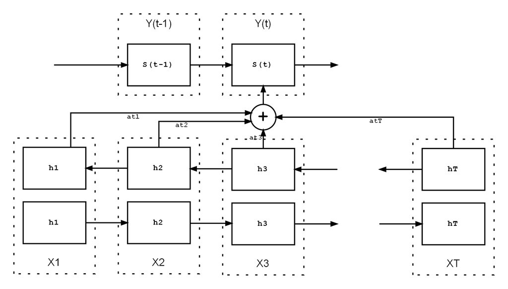

Attention mechanism eases up the bottleneck problems of RNN models since their encoders and decoders deal with the entirety of the sequences. As the name implies, a natural approach is to focus, weigh the intermediate hidden values. These weights adjust the amount of attention a model must pay to input in each decoding step (a *context* vector).

The attention mechanism determines how each word is related to all other words in a sequence, including the word being analyzed itself. In a way, the attention mechanism helps RNN focus on certain parts of the input sequence when predicting a certain part of the output sequence, making the learning process better. Some examples of attention mechanisms as provided below.

| Name | Score | Reference |
| --- | --- | --- |
| Content-based | $\operatorname{score}(\mathbf{s}_t,\mathbf{h}_i) = \operatorname{cosine}[\mathbf{s}_t,\mathbf{h}_i]$ | Graves14 |
| Additive | $$\operatorname{score}(\mathbf{s}_t,\mathbf{h}_i) = v_a^\top \operatorname{tanh}(\mathbf{W}_a [\mathbf{s}_t,\mathbf{h}_i])$$ | Bahdanau15 |
| Location-based | $\alpha_{t,i} = \operatorname{softmax}(\mathbf{W}_a \mathbf{s}_t)$ | Loung15 |
| General | $\operatorname{score}(\mathbf{s}_t,\mathbf{h}_i) = \mathbf{s}_t^\top \mathbf{W}_a \mathbf{h}_i$ | Loung15 |
| Dot-product | $\operatorname{score}(\mathbf{s}_t,\mathbf{h}_i) = \mathbf{s}_t^\top \mathbf{h}_i$ | Loung15 |
| Scaled dot-product | $\operatorname{score}(\mathbf{s}_t,\mathbf{h}_i) = \frac{\mathbf{s}_t^\top \mathbf{h}_i}{\sqrt n}$ | Vaswani17 |

### Multi-head Attention Mechanism

Self-attention involves three matrices `Q`, `K` and `V` all derived from the original corpus and the input `X` $\in \mathbb{R}^{d_x \times d_{\text{model}}}$ where there are $d_x$ tokens in the sequence and an embedding of size $d_{\text{model}}$. The original length of the sequence is either $d_x$ or truncated to $d_x$. All three matrices `Q` (query $\theta$), `K` (key $\Phi$) and `V` (value $\mathbf{g}$) are achieved multiplying the `X` matrix by $\Theta$, $\Phi$, and $\mathbf{g}$, respectively. The values (weights) of these matrices are trained by the learning process.

`Q` and `K` multiplied to each other generates the attention score matrix. This can also be seen as a database using the query and keys in order to find out how much various items are related. Multiplication of the attention score and `V` produces the final result.

$\operatorname{Attention}(Q,K,V) = V \operatorname{softmax}(\operatorname{score}(Q,K))$

Similar to neural network training, `Q`, `K` and `V` are initialized randomly with a particular distribution (e.g. zero mean a low standard deviation normal) and then trained with the corpus.

Multi-head attention repeats this process for a $k$ number of times and concatenates the output linearly to achieve parallelism. If there are $k$ heads then the output attention will be $Z = (z_0,z_1,\dots,z_{k-1})$ partitioned over $\frac{d_{\text{model}}} {k}$, embedding dimension size.

## The Transformer Model

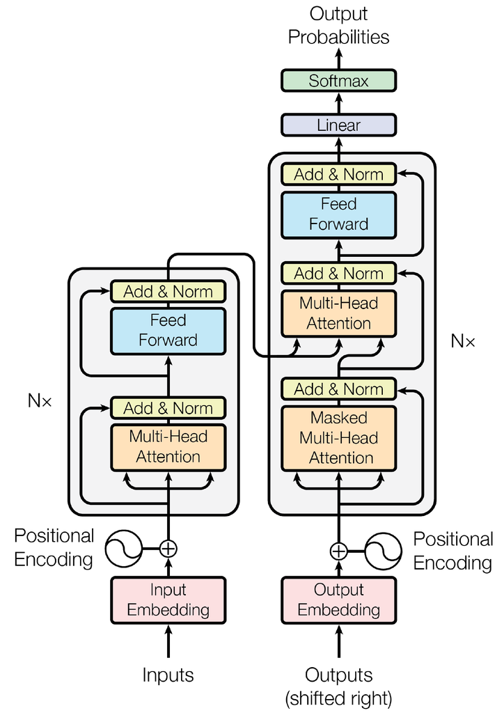

The novelty called Transformer is an architecture for transforming one sequence into another one with the help of an Encoder and Decoder stages. It differs from the previous sequence-to-sequence models because it does not use a Recurrent Neural Networks (such as GRU, LSTM). It uses the attention mechanism in place of an RNN which results in more successful translation, summarization and other sequence related tasks. One example model is BERT (Deep Bidirectional Transformers for Language Understanding).

The Encoder is on the left and the Decoder is on the right. Both Encoder and Decoder are composed of modules that can be stacked on top of each other multiple times, which is described by Nx in the figure. The modules consist mainly of multi-head attention and feed forward layers. The inputs and outputs (such as tokenized target sentences) are embedded into a feature space.

Another addition is the positional encoding of the consecutive tokens. Since there is no recurrent network that can remember how tokens are ordered in a sequence, the provided relative positions carry this information. These positions are added to the embedded representation of each token.

In this model, a particular word refers to different entities in different contexts. Another improvement made is the parallel processing by dropping the NN feedback architecture. Regular sequential recurrent models such as LSTMs and GRUs are slow because they process the input token by token. The feed-forward layers in the transformer model run faster because single matrix multiplication is faster than a recurrent unit. Lastly, stacks of multi-head attention layers model better representation of complex sentences.

### Add and Norm

This layer adds and normalizes the outputs from the multi-head attention block with layer normalization which is normalizing the inputs to a layer across all features.

## Transfer Learning

Transfer Learning (TL) is a field of AI working to develop models reusable for different tasks such as, a model trained on a task A is reusable (with fine-tuning) on task B. In NLP, this is clearer as a Transformer model can capture the understanding of the language itself. Shallow TL in NLP involves Word2vec, GloVe, and Doc2vec models. These models are called shallow because there is no model behind this kind of TL and instead, the pre-trained vectors for words/tokens are utilized. These token- or document-embedding models are followed by a classifier to achieve better performance as we explored them in the previous lectures.

TL in NLP using Transformer models is also possible because these models can learn a language itself without any labeled data. Language modeling is a task used to train transferable weights for various problems. Masked language modeling is one of the methods used to learn a language itself. As with Word2vec's window-based model for predicting center tokens, in masked language modeling, a similar approach takes place, with key differences. Given a probability, each word is masked and replaced with a special token such as `[MASK]`. The language model predicts the masked words. Instead of using a window, unlike with Word2vec, a whole sentence is given, and the output of the model must be the same sentence with masked words filled.

One of the first models that used the Transformer architecture for language modeling is BERT, which is based on the encoder part of the Transformer architecture. Masked language modeling is accomplished by BERT by using the same method described before and after training a language model. BERT is a transferable language model for different NLP tasks such as token classification, sequence classification, or question answering.

Each of these tasks is a fine-tuning task for BERT once a language model is trained. BERT is best known for its key characteristics on the base Transformer encoder model, and by altering these characteristics, different versions such as small, tiny, base, large, and extra-large models are proposed. Contextual embedding enables a model to have the correct meaning of each word based on the context in which it is given.

[Hugging Face](https://huggingface.co/models) has numerous community models provided by collaborators from organizations.

### Training BERT Models

A pre-training is not crucial when an already pre-trained BERT model can be transferred. However, training massive datasets, which in turn further improves the state-of-the-art accuracy, is a daunting task. For example, BERT is generally pre-trained on a concatenation of BooksCorpus (800 million words) and the English Wikipedia (2.5 billion words), to form a total dataset of 3.3 billion words as cited by Nvidia, [utilizing a very large cluster of GPGPUs](https://developer.nvidia.com/blog/training-bert-with-gpus/) for training.

Install transformers in a new environment:  
`conda create -n nlp jupyter matplotlib pandas scikit-learn nltk`↩  
`conda activate nlp`↩  
`conda install pytorch torchvision torchaudio pytorch-cuda=12.1 -c pytorch -c nvidia`↩  
`conda install transformers datasets`↩

Here is the [Transformers API](https://huggingface.co/docs/transformers/index).

## Multi-head Attention

The multi-head attention block is the main innovation behind transformers. This block finds out what parts of the text should the model focus on. A single attention block can set a model to *pay attention* to something specific such as the verb in a sentence. Using multiple attention blocks can focus to different linguistic elements such as part of speech, nouns, verbs, adjectives, etc.

## Effect of Positional Encoding

The idea is to arithmetically **add** a positional encoding value to the input embedding instead of having additional vectors to specify the position of a token in a sequence. Provide sine and cosine functions to generate different frequencies for the positional encoding (PE) for each position and each dimension $i$ of the word embedding vector (size $d_{\text{model}}$). According to the functions below there can be `N=`10,000 positions to encode by sine and cosine values with wavelengths that increase geometrically from $2 \pi$ to $20000 \pi$.

$\operatorname{PE}_{(pos 2i)} = \sin (\frac{pos}{10000^ {\frac{2i}{d_{\text{model}}}}})$, and, $\operatorname{PE}_{(pos 2i+1)} = \cos (\frac{pos}{10000^ {\frac{2i}{d_{\text{model}}}}})$

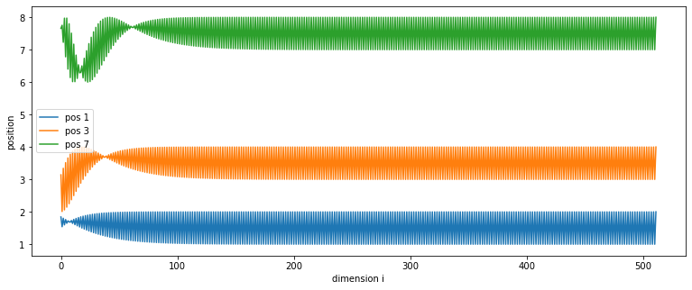

```python
%matplotlib inline
import matplotlib.pyplot as plt
plt.rcParams["figure.dpi"] = 72
import numpy as np
import pandas as pd
import os


# demonstration, each pe vector to be added to their respective word embedding vectors
N_pe = 10000
d_model = 512

def pos_encode(pos):
    pe = np.zeros(d_model, dtype=float)
    for i in range(0, d_model, 2):
        pe[i  ] = np.sin(pos / (N_pe ** ((2.*i)/d_model)))
        pe[i+1] = np.cos(pos / (N_pe ** ((2.*i)/d_model)))
    return pe

plt.figure(figsize=(13,5), dpi=72)
plt.plot(1+pos_encode(1), label='pos 1')
plt.plot(3+pos_encode(3), label='pos 3')
plt.plot(7+pos_encode(7), label='pos 7')
plt.xlabel('dimension i')
plt.ylabel('position')
plt.legend()
plt.show()
```

## Tokenizer

NLP pipeline starts with some kind of tokenization since the features of text are words separated and delimited by white space. A tokenizer breaks unstructured data and natural language text into chunks of information that can be considered as discrete elements. These tokens can be used directly as a vector representing that document before a word embedding stage. A word embedding transforms token vectors in a better subspace of tokens where vectors are not orthogonal but the distances between them are related to how close semantically (or contextually) the tokens are to each other, such as in {man-woman} $\leftrightarrow$ {king-queen} relation.

Below cell imports the BERT tokenizer, and then downloads a pretrained tokenizer for BERT. Each tokenizer has its own way of adding special tokens to the original sequence. In the case of the BERT tokenizer, it adds a `[CLS]` token to the beginning and an `[SEP]` token to the end of the sequence, which can be seen by `101` and `102`. These numbers come from the token IDs of the pretrained tokenizer.

**Note** Check token type_ids from transformers website.

```python
MODEL_PATH= '../../../EP_models/'
os.environ['TRANSFORMERS_CACHE']= MODEL_PATH  # before import transformers
os.environ['HF_DATASETS_CACHE']= MODEL_PATH  # dataset cache

os.environ['CUDA_VISIBLE_DEVICES']= '0'  # assume single GPU

import transformers

# filter warnings
transformers.logging.set_verbosity_error()

print(f'transformers version= {transformers.__version__}')
```

```
transformers version= 4.32.1
```

**Notice** the word `meh` is not known by the pretrained tokenizer and represents it by suffixes on known words. This would work for most words such as `thing` and `thingy` which would probably close to the `thing` but probably would not work for `meh` which is a slang word.

```python
from transformers import BertTokenizer

tokenizer = BertTokenizer.from_pretrained('bert-base-uncased', do_lower_case=True)

# example
text = "The universe is transformation, meh, life is opinion."

# tokenized IDs
tokenized_sequence = tokenizer.tokenize(text)
print(tokenized_sequence)


inputs = tokenizer(text)
print(inputs)

encoded_sequence = inputs['input_ids']
print(encoded_sequence)

# sanity
decoded_sequence = tokenizer.decode(encoded_sequence)
print(decoded_sequence)
```

```
['the', 'universe', 'is', 'transformation', ',', 'me', '##h', ',', 'life', 'is', 'opinion', '.']
{'input_ids': [101, 1996, 5304, 2003, 8651, 1010, 2033, 2232, 1010, 2166, 2003, 5448, 1012, 102], 'token_type_ids': [0, 0, 0, 0, 0, 0, 0, 0, 0, 0, 0, 0, 0, 0], 'attention_mask': [1, 1, 1, 1, 1, 1, 1, 1, 1, 1, 1, 1, 1, 1]}
[101, 1996, 5304, 2003, 8651, 1010, 2033, 2232, 1010, 2166, 2003, 5448, 1012, 102]
[CLS] the universe is transformation, meh, life is opinion. [SEP]
```

## Masked Language Modeling

Masked language modelling and image modelling can be considered similar to autoencoding modelling which works based on constructing outcomes from unarranged or corrupted input. As the name suggests, masking works with these modelling procedures which means we mask words from a sequence of input or sentences and the designed model needs to predict the masked words to complete the sentence. Masked language modeling does not require training a model with a sequence of visible words followed by a masked sequence to predict. BERT introduces the bidirectional analysis of a sentence with a random mask on a word of the sentence.

```python
from transformers import pipeline

# MLM model
unmasker = pipeline('fill-mask', model='bert-base-uncased', top_k=5)

display(pd.DataFrame(unmasker("The best movie was [MASK].")))
```

|  | score | token | token_str | sequence |
| --- | --- | --- | --- | --- |
| 0 | 0.037648 | 2180 | won | the best movie was won. |
| 1 | 0.030593 | 2439 | lost | the best movie was lost. |
| 2 | 0.025292 | 2033 | me | the best movie was me. |
| 3 | 0.022631 | 2908 | gone | the best movie was gone. |
| 4 | 0.021140 | 4222 | nominated | the best movie was nominated. |

```python
# What is the most probable word/tag after 'homework' in the following sentence
display(pd.DataFrame(unmasker("Please turn your homework [MASK].")))

# Answer: A preposition
```

|  | score | token | token_str | sequence |
| --- | --- | --- | --- | --- |
| 0 | 0.799295 | 2058 | over | please turn your homework over. |
| 1 | 0.079212 | 2105 | around | please turn your homework around. |
| 2 | 0.031670 | 2125 | off | please turn your homework off. |
| 3 | 0.021569 | 2006 | on | please turn your homework on. |
| 4 | 0.016496 | 1999 | in | please turn your homework in. |

```python
# What is the most probable word/tag after 'chess' in the following sentence
display(pd.DataFrame(unmasker("We played a game on the chess [MASK].")))

# Answer: the game 'board'
```

|  | score | token | token_str | sequence |
| --- | --- | --- | --- | --- |
| 0 | 0.459528 | 6277 | ##board | we played a game on the chessboard. |
| 1 | 0.226204 | 2604 | board | we played a game on the chess board. |
| 2 | 0.054282 | 2795 | table | we played a game on the chess table. |
| 3 | 0.037166 | 2723 | floor | we played a game on the chess floor. |
| 4 | 0.016036 | 2457 | court | we played a game on the chess court. |

## Text Classification

### GLUE Benchmark

The [GLUE benchmark](https://gluebenchmark.com) has been introduced as a collection of tools and datasets for evaluating the performance models across a list of tasks. This benchmark includes many sentence understanding tasks that are based on various datasets of differing size, text type, and difficulty levels.

- Single sentence tasks
  1. CoLA: The Corpus of Linguistic Acceptability dataset - consists of English acceptability judgments drawn from articles on linguistic theory
  2. SST-2: The Stanford Sentiment Treebank dataset - includes sentences from movie reviews and human annotations of their sentiment with pos/neg labels
- Similarity and paraphrase tasks
  1. MRPC: The Microsoft Research Paraphrase Corpus dataset - examines whether the sentences in a pair are semantically equivalent
  2. QQP: The Quora Question Pairs dataset - decides whether a pair of questions is semantically equivalent
  3. STS-B: The Semantic Textual Similarity Benchmark dataset - collection of sentence pairs drawn from news headlines, with a similarity score between 1 and 5
- Inference tasks
  1. MNLI: The Multi-Genre Natural Language Inference corpus - a collection of sentence pairs with textual entailment. The task is to predict whether the text entails a hypothesis (entailment), contradicts the hypothesis (contradiction), or neither (neutral)
  2. QNLI: Question Natural Language Inference dataset - a converted version of SquAD. The task is to check whether a sentence contains the answer to a question.
  3. RTE: The Recognizing Textual Entailment dataset - a task of textual entailment challenges combining data from various sources; similar to the previous QNLI dataset, where the task is to check whether a first text entails a second one
  4. WNLI: The Winograd Natural Language Inference schema challenge - a pronoun resolution task linking a pronoun and a phrase in a sentence

GLUE benchmark [dataset details](https://huggingface.co/datasets/glue)

```python
%env PYTORCH_CUDA_ALLOC_CONF=max_split_size_mb:100
# avoid memory fragmentation

import torch

# set GPGPU device
Device = torch.device('cuda:0' if torch.cuda.is_available() else 'cpu')
n_gpu = torch.cuda.device_count()
print(torch.cuda.get_device_name(0))
```

```
env: PYTORCH_CUDA_ALLOC_CONF=max_split_size_mb:100
NVIDIA RTX A6000
```

```python
# dataset
df = pd.read_csv("../../../EP_datasets/cola_public/raw/in_domain_train.tsv", delimiter='\t', header=None,
                 names=['sentence_source', 'label', 'label_notes', 'sentence'])

print(df.shape)

# Adding CLS and SEP tokens at the beginning and end of each sentence for BERT
sentences_tr = ["[CLS] " + s + " [SEP]" for s in df.sentence.values]

# labels
df_labels_tr = df.label.values
print('balance:', np.unique(df_labels_tr, return_counts=True))
```

```
(8551, 4)
balance: (array([0, 1], dtype=int64), array([2528, 6023], dtype=int64))
```

```python
# Download the tokenizer for a pre-trained BERT model
tokenizer = BertTokenizer.from_pretrained('bert-base-uncased', do_lower_case=True)

tokenized_texts_tr = [tokenizer.tokenize(s) for s in sentences_tr]

# sanity
print ('Tokenized:',tokenized_texts_tr[0])

# longest sequence
print('longest seq=', np.array([len(t) for t in tokenized_texts_tr]).max())
```

```
Tokenized: ['[CLS]', 'our', 'friends', 'won', "'", 't', 'buy', 'this', 'analysis', ',', 'let', 'alone', 'the', 'next', 'one', 'we', 'propose', '.', '[SEP]']
longest seq= 47
```

```python
# Pad input tokens to top MAX_LEN which is a bit longer than the longest input sequence
MAX_LEN = 64

# Use the BERT tokenizer to convert the tokens to their index numbers in the BERT vocabulary
X_ids_tr = [tokenizer.convert_tokens_to_ids(x) for x in tokenized_texts_tr]

# since PAD is 0, top the sequence to MAX_LEN with 0
print('pad id=', tokenizer.convert_tokens_to_ids('[PAD]'))

for i, seq in enumerate(X_ids_tr):
    n = MAX_LEN-len(seq)
    X_ids_tr[i] += [0]*n

print(len(X_ids_tr[3]))
```

```
pad id= 0
64
```

```python
# Create an attention mask of 1s for each token followed by 0s for padding
def get_masks(_X):
    attention_masks = []
    for seq in _X:
        attention_masks += [[float(_>0) for _ in seq]]
    return attention_masks
```

```python
# Prepare dataset, tensors and iterator
from sklearn.model_selection import train_test_split

X_tr, X_val, y_tr, y_val = train_test_split(X_ids_tr, df_labels_tr, random_state=0, test_size=0.1)
mask_tr, mask_val, _, _ = train_test_split(get_masks(X_ids_tr), X_ids_tr, random_state=0, test_size=0.1)

X_tr, X_val, y_tr, y_val = torch.tensor(X_tr), torch.tensor(X_val), torch.tensor(y_tr), torch.tensor(y_val)
mask_tr, mask_val = torch.tensor(mask_tr), torch.tensor(mask_val)
```

```python
from torch.utils.data import TensorDataset, DataLoader, RandomSampler, SequentialSampler

BATCH_SIZE = 32

dataset_tr = TensorDataset(X_tr, mask_tr, y_tr)
dataloader_tr = DataLoader(dataset_tr, sampler=RandomSampler(dataset_tr), batch_size=BATCH_SIZE)

dataset_val = TensorDataset(X_val, mask_val, y_val)
dataloader_val = DataLoader(dataset_val, sampler=SequentialSampler(dataset_val), batch_size=BATCH_SIZE)
```

```python
from transformers import BertConfig, BertModel, BertForSequenceClassification

# BERT model and configuration
model = BertModel(BertConfig())

print(model.config)
```

```
BertConfig {
  "attention_probs_dropout_prob": 0.1,
  "classifier_dropout": null,
  "hidden_act": "gelu",
  "hidden_dropout_prob": 0.1,
  "hidden_size": 768,
  "initializer_range": 0.02,
  "intermediate_size": 3072,
  "layer_norm_eps": 1e-12,
  "max_position_embeddings": 512,
  "model_type": "bert",
  "num_attention_heads": 12,
  "num_hidden_layers": 12,
  "pad_token_id": 0,
  "position_embedding_type": "absolute",
  "transformers_version": "4.32.1",
  "type_vocab_size": 2,
  "use_cache": true,
  "vocab_size": 30522
}
```

```python
model = BertForSequenceClassification.from_pretrained('bert-base-uncased', num_labels=2)
model.to(Device) ;  # displays the entire neural network
```

```python
# 'weight' parameters 'weight_decay_rate' of 0.01, 'bias' parameters 'weight_decay_rate' is 0.0
param_optimizer = list(model.named_parameters())
no_decay = ['bias', 'LayerNorm.weight']

optimizer_grouped_parameters = [
    {'params': [p for n, p in param_optimizer if not any(nd in n for nd in no_decay)], 'weight_decay_rate': 0.1},
    {'params': [p for n, p in param_optimizer if any(nd in n for nd in no_decay)], 'weight_decay_rate': 0.0}
]
```

```python
from torch.optim import AdamW
from transformers import get_linear_schedule_with_warmup

EPOCHS = 4

optimizer = AdamW(optimizer_grouped_parameters, lr=2e-5, eps = 1e-8)

total_steps = len(dataloader_tr)*EPOCHS

scheduler = get_linear_schedule_with_warmup(optimizer, num_warmup_steps=0, num_training_steps=total_steps)
```

```python
def accuracy_logits(_logits, _y):
    ypred = [0 if _[0]>_[1] else 1 for _ in _logits]
    return np.sum([ypred[_]==_y[_] for _ in range(len(ypred))]) / len(ypred)
```

```python
%%time

# manual training loop, fine-tune
loss_train = []
for _ in range(EPOCHS):
    model.train()  # set to training mode
    cost, n = 0, 1
    for n, batch in enumerate(dataloader_tr):
        X_b, mask_b, y_b = tuple(t.to(Device) for t in batch)  # send batch to device
        optimizer.zero_grad()
        # NN forward
        outputs = model(X_b, token_type_ids=None, attention_mask=mask_b, labels=y_b)
        loss = outputs['loss']
        loss_train += [loss.item()]
        cost += loss.item()
        loss.backward()
        optimizer.step()
        scheduler.step()
    print(f'Train loss= {cost/n:.3f}')
    # Evaluation
    model.eval()  # set to non-training mode
    acc = 0
    for n, batch in enumerate(dataloader_val):
        X_b, mask_b, y_b = tuple(t.to(Device) for t in batch)
        with torch.no_grad():
            logits = model(X_b, token_type_ids=None, attention_mask=mask_b)
        acc += accuracy_logits(logits['logits'].detach().cpu().numpy().tolist(), y_b.to('cpu').tolist())
    print(f'Validation accuracy= {acc/n:.3f}')
```

```
Train loss= 0.504
Validation accuracy= 0.855
Train loss= 0.310
Validation accuracy= 0.875
Train loss= 0.198
Validation accuracy= 0.876
Train loss= 0.133
Validation accuracy= 0.873
CPU times: total: 1min 29s
Wall time: 1min 30s
```

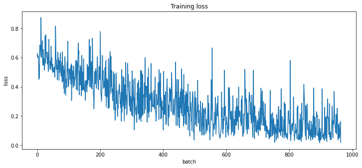

```python
# training progress
plt.figure(figsize=(12,5), dpi=72)
plt.xlabel('batch')
plt.ylabel('loss')
plt.title('Training loss')
plt.plot(loss_train)
plt.show()
```

```python
# test performance
df = pd.read_csv("../../../EP_datasets/cola_public/raw/out_of_domain_dev.tsv", delimiter='\t', header=None,
                 names=['sentence_source', 'label', 'label_notes', 'sentence'])

# Adding CLS and SEP tokens at the beginning and end of each sentence for BERT
sentences_ts = ["[CLS] " + s + " [SEP]" for s in df.sentence.values]

# labels
df_labels_ts = df.label.values
print('balance:', np.unique(df_labels_ts, return_counts=True))

tokenized_texts_ts = [tokenizer.tokenize(s) for s in sentences_ts]

X_ids_ts = [tokenizer.convert_tokens_to_ids(x) for x in tokenized_texts_ts]

# pad 0
for i, seq in enumerate(X_ids_ts):
    n = MAX_LEN-len(seq)
    X_ids_ts[i] += [0]*n

X_ts, y_ts, mask_ts = torch.tensor(X_ids_ts), torch.tensor(df_labels_ts), torch.tensor(get_masks(X_ids_ts))
dataset_ts = TensorDataset(X_ts, mask_ts, y_ts)
dataloader_ts = DataLoader(dataset_ts, sampler=SequentialSampler(dataset_ts), batch_size=BATCH_SIZE)
```

```
balance: (array([0, 1], dtype=int64), array([162, 354], dtype=int64))
```

```python
# predict
y_logits, y_ts = [], []
model.eval()
for batch in dataloader_ts:
    X_b, mask_b, y_b = tuple(t.to(Device) for t in batch)
    with torch.no_grad():
        logits = model(X_b, token_type_ids=None, attention_mask=mask_b)
    logits = logits['logits'].detach().cpu().numpy()
    y_logits += logits.tolist()
    y_ts += y_b.to('cpu').tolist()

print(f'CoLa benchmark accuracy= {accuracy_logits(y_logits, y_ts):.2f}')
```

```
CoLa benchmark accuracy= 0.82
```

## Roberta CoLA Model

Let's try a specific model and use a `Trainer`.

```python
from transformers import RobertaForSequenceClassification

# filter warnings
transformers.logging.set_verbosity_error()

torch.cuda.empty_cache()  # save memory

model2 = RobertaForSequenceClassification.from_pretrained('roberta-base', num_labels=2)

model2.to(Device) ;  # displays the entire neural network
```

```python
from torch import cuda
from transformers import TrainingArguments, Trainer

args_tr = TrainingArguments(
    output_dir= MODEL_PATH+'/model_module11',
    do_train= True,
    do_eval= True,
    eval_steps= 100,
    evaluation_strategy= 'epoch',
    num_train_epochs= 4,
    per_device_train_batch_size= 16,
    per_device_eval_batch_size= 32,
    warmup_steps= 200,
    weight_decay= 0.1,
    logging_strategy= 'epoch',
    logging_dir= './logs',
    logging_steps= 100,
    fp16= cuda.is_available(),
    save_strategy= 'epoch',
    load_best_model_at_end= True,
    report_to= None,
    optim= 'adamw_torch'
)
```

```python
def metrics(_pred):
    from sklearn.metrics import accuracy_score
    labels = _pred.label_ids
    preds = _pred.predictions.argmax(-1)
    acc_ = accuracy_score(labels, preds)
    return {
        'Accuracy': acc_
    }
```

```python
from transformers import RobertaTokenizer

tokenizer = RobertaTokenizer.from_pretrained('roberta-base', do_lower_case=True)
```

```python
import datasets

# filter warnings
datasets.logging.set_verbosity_error()

cola_tr = datasets.load_dataset('glue', 'cola', split='train')
cola_ts = datasets.load_dataset('glue', 'cola', split='test')
cola_val = datasets.load_dataset('glue', 'cola', split='validation')
```

```python
MAX_LENGTH = 32

def getX(_sents):
    return tokenizer(_sents, truncation=True, padding=True, max_length=MAX_LENGTH)

class ColaDataset(torch.utils.data.Dataset):
    def __init__(self, encodings, labels):
        self.encodings = encodings
        self.labels = labels

    def __getitem__(self, idx):
        item = {key: torch.tensor(val[idx]) for key, val in self.encodings.items()}
        item['labels'] = torch.tensor(self.labels[idx])
        return item

    def __len__(self):
        return len(self.labels)

dataset_tr = ColaDataset(getX(cola_tr['sentence']), cola_tr['label'])
dataset_val = ColaDataset(getX(cola_val['sentence']), cola_val['label'])
```

```python
# sanity
# getX(cola_tr['sentence'])
```

```python
# sanity
# dataset_tr[0]
```

```python
%%time

trainer = Trainer(model=model2, args=args_tr, train_dataset=dataset_tr, eval_dataset=dataset_val, compute_metrics=metrics)

trainer.train()
```

```
{'loss': 0.5762, 'learning_rate': 4.144329896907217e-05, 'epoch': 1.0}
{'eval_loss': 0.5178589224815369, 'eval_Accuracy': 0.7459252157238735, 'eval_runtime': 0.6796, 'eval_samples_per_second': 1534.703, 'eval_steps_per_second': 48.557, 'epoch': 1.0}
{'loss': 0.4229, 'learning_rate': 2.7654639175257735e-05, 'epoch': 2.0}
{'eval_loss': 0.49779045581817627, 'eval_Accuracy': 0.8216682646212847, 'eval_runtime': 0.6758, 'eval_samples_per_second': 1543.293, 'eval_steps_per_second': 48.829, 'epoch': 2.0}
{'loss': 0.275, 'learning_rate': 1.38659793814433e-05, 'epoch': 3.0}
{'eval_loss': 0.47398585081100464, 'eval_Accuracy': 0.8293384467881112, 'eval_runtime': 0.675, 'eval_samples_per_second': 1545.179, 'eval_steps_per_second': 48.889, 'epoch': 3.0}
{'loss': 0.1896, 'learning_rate': 1.0309278350515465e-07, 'epoch': 4.0}
{'eval_loss': 0.7216147184371948, 'eval_Accuracy': 0.8293384467881112, 'eval_runtime': 0.6654, 'eval_samples_per_second': 1567.46, 'eval_steps_per_second': 49.594, 'epoch': 4.0}
{'train_runtime': 173.0835, 'train_samples_per_second': 197.616, 'train_steps_per_second': 12.364, 'train_loss': 0.3659248423353534, 'epoch': 4.0}
CPU times: total: 2min 47s
Wall time: 2min 53s
```

```
TrainOutput(global_step=2140, training_loss=0.3659248423353534, metrics={'train_runtime': 173.0835, 'train_samples_per_second': 197.616, 'train_steps_per_second': 12.364, 'train_loss': 0.3659248423353534, 'epoch': 4.0})
```

```python
# save the model
model_fn = MODEL_PATH+'/trained_model11'
trainer.save_model(model_fn) ;
```

```python
model2.cpu()  # release Gpu memory

# load the model
model3 = RobertaForSequenceClassification.from_pretrained(model_fn, num_labels=2)
model3.to(Device)

# Define test trainer
trainer = Trainer(model3)

# Anything not in original labels will cause CUDA device exception
dataset_ts = ColaDataset(getX(cola_ts['sentence']), [0]*len(cola_ts['label']))

# Make the prediction
raw_pred, _, _ = trainer.predict(dataset_ts, ignore_keys=['labels'])

# Preprocess raw predictions
y_pred = np.argmax(raw_pred, axis=1)

# sanity
raw_pred[:10]
```

```
array([[-1.6845703 ,  1.8964844 ],
       [ 0.01304626,  0.53271484],
       [-1.9404297 ,  2.1132812 ],
       [-1.7216797 ,  1.9863281 ],
       [ 0.9169922 , -0.40478516],
       [-1.8115234 ,  2.0488281 ],
       [-1.4267578 ,  1.7158203 ],
       [-0.06671143,  0.51953125],
       [-0.8598633 ,  1.2861328 ],
       [-1.6914062 ,  1.9414062 ]], dtype=float32)
```

```python
# reclassification performance
q = [trainer.evaluate(eval_dataset=data) for data in [dataset_tr, dataset_val]]
```

```
{'eval_loss': 0.1410766988992691, 'eval_runtime': 21.2614, 'eval_samples_per_second': 402.184, 'eval_steps_per_second': 50.279}
{'eval_loss': 0.47398683428764343, 'eval_runtime': 2.5094, 'eval_samples_per_second': 415.643, 'eval_steps_per_second': 52.204}
```

## Transformers Applications

Roberts (2019) designed a transformer meta-model based on the simple assertion that,

> Every NLP problem can be represented as a text-to-text function. Every type of NLP task provides some kind of text context that generates some form of text response. A text-to-text representation of any NLP task provides a unique framework to analyze transformers' methodology and practice. The idea is for a transformer to learn a language through transfer learning during the training and fine-tuning phases with a text-to-text approach.

This model is named as **T5** from the phrase a Text-To-Text Transfer Transformer.

Designing a universal text-to-text model utilized first the NLP technical revolution started with Vaswani (2017), the original Transformer. The second progress towards a *magical solution* was OpenAI GPT-2 and GPT-3 Models focusing taking transformer models from fine-tuning pretrained models to few-shot trained models that required no fine-tuning. Boldly, the second step was to show that a machine can learn a language and apply it to downstream tasks as we humans do.

Humans learn a language and then apply that knowledge to a wide range of NLP tasks through transfer learning. The core concept of a T5 model is to find an abstract model that can do things like us. When humans communicate, we always start with a sequence that is followed by another sequence which in turn, becomes the start sequence leading to another. Similarly, music also is composed of organized sounds, dancing with organized body movements, painting with coordinated shapes and colors, and finally language with a word or a group of words we call *text.* Understanding text requires attention to all of the words in the sentence in all directions, measuring the importance of each term. If a sentence is confusing, we focus on a word and query the rest of the keywords in the sentence to determine their values and the attention we must pay to them. This defines the attention layers of transformers.

Reading comprehension requires many skills applied all at once. Reading a text involves parsing the keywords and the main events, and then creating some kind of representations of the content, probably built on past experience and knowledge. Summarization can be done by applying text-to-text transformations. Questions can be answered using the knowledge of the content and the representations built. In addition, each question is examined to avoid traps and making mistakes.

## Sentiment Analysis

The principle of compositionality is the paradigm that the meaning of a complex expression is determined by the meanings of its ingredient expressions and the rules used to combine them. Sentiment analysis relies on the principle of compositionality. Understanding parts of a sentence helps understanding a whole sentence. NLP transformer models can accomplish the user emotion detection task via various models as in below sections.

## Summarization

NLP summarizing tasks extract succinct parts of a text. Below, a T5-large transformer model will be used to summarize any type of document, including legal and corporate documents.

The T5 module requires a library: `conda install -c conda-forge sentencepiece`

**Note:** Restart the kernel after installing new libraries.

## Questions and Answers

Transformers are powerful state-of-the-art models but still they cannot answer open questions easily. An open environment means that somebody can ask any question on any topic, and a transformer would answer correctly. That is still impossible to accomplish. If they could, perhaps a Turing test could be beaten?

Transformers often use general domain training datasets in a closed question-and-answer environment. For example, critical answers in medical care and law interpretation require additional NLP functionality. However, transformers cannot answer any question correctly regardless of whether the training environment is closed with preprocessed question-answer sequences or not. If a sequence contains more than one subject and compound propositions, a transformer model can make wrong predictions.

Below, a DistilBERT model is used to answer questions by introducing Named Entity Recognition (NER) functions that suggest reasonable questions.

## Sentiment Analysis

```python
nlp_cls = pipeline('sentiment-analysis', device=Device)  # gpu device
```

```python
Text = "The battery on my Model9X phone doesn't last more than 6 hours and I'm unhappy about that."
nlp_cls(Text)
```

```
[{'label': 'NEGATIVE', 'score': 0.9987226128578186}]
```

```python
Text = "They were not playing basketball since the playground was inaccessible"
nlp_cls(Text)
```

```
[{'label': 'NEGATIVE', 'score': 0.9970545768737793}]
```

```python
Text = "They were playing basketball in the mud since the playground was soaked after a storm"
nlp_cls(Text)
```

```
[{'label': 'NEGATIVE', 'score': 0.9975960850715637}]
```

```python
Text = "They were playing basketball at the court"
nlp_cls(Text)
```

```
[{'label': 'POSITIVE', 'score': 0.522497296333313}]
```

```python
Text = "I was so excited to see Joffrey was poisoned"
nlp_cls(Text)
```

```
[{'label': 'NEGATIVE', 'score': 0.9216068983078003}]
```

```python
Text = "I was so excited to see Joffrey was saved"
nlp_cls(Text)
```

```
[{'label': 'POSITIVE', 'score': 0.9996500015258789}]
```

```python
Text = "I could not care less about Joffrey"
nlp_cls(Text)
```

```
[{'label': 'POSITIVE', 'score': 0.753743052482605}]
```

```python
Text = ["I am happy", "I am very happy", "I am seldom happy", "I am not happy", "I am unhappy", "I could be happier"]
nlp_cls(Text)
```

```
[{'label': 'POSITIVE', 'score': 0.9998801946640015},
 {'label': 'POSITIVE', 'score': 0.9998795986175537},
 {'label': 'NEGATIVE', 'score': 0.9992653727531433},
 {'label': 'NEGATIVE', 'score': 0.9997896552085876},
 {'label': 'NEGATIVE', 'score': 0.9997407793998718},
 {'label': 'NEGATIVE', 'score': 0.9580811858177185}]
```

## Summarization Example

```python
import torch
from transformers import T5Tokenizer, T5ForConditionalGeneration, T5Config

# might require `pip install protobuf`

# set GPGPU device
Device = torch.device('cuda' if torch.cuda.is_available() else 'cpu')
print(torch.cuda.get_device_name(0))

model = T5ForConditionalGeneration.from_pretrained('t5-large')
model.to(Device)

tokenizer = T5Tokenizer.from_pretrained('t5-large', model_max_length=512, legacy=False)
```

```
NVIDIA RTX A6000
```

```python
def summarize(_model, _tokenizer, _text, _maxlen):
    preprocess_text = _text.strip().replace('\n',' ')
    t5_prepared_text = "summarize: " + preprocess_text
    print("Preprocessed and prepared text:\n", t5_prepared_text)

    tokenized_text = _tokenizer.encode(t5_prepared_text, return_tensors="pt").to(Device)

    # summmarize
    summary_ids = _model.generate(tokenized_text,
                                  num_beams=4,
                                  no_repeat_ngram_size=2,
                                  min_length=30,
                                  max_length=_maxlen,
                                  early_stopping=True)

    output = _tokenizer.decode(summary_ids[0], skip_special_tokens=True)
    return output
```

```python
Text = """
The United States Declaration of Independence was the first Etext
released by Project Gutenberg, early in 1971.  The title was stored
in an emailed instruction set which required a tape or diskpack be
hand mounted for retrieval.  The diskpack was the size of a large
cake in a cake carrier, cost $1500, and contained 5 megabytes, of
which this file took 1-2%.  Two tape backups were kept plus one on
paper tape.  The 10,000 files we hope to have online by the end of
2001 should take about 1-2% of a comparably priced drive in 2001.
"""

print("Number of characters:", len(Text))
summary = summarize(model, tokenizer, Text, 64)
print ("\n\nSummarized text: \n", summary)
```

```
Number of characters: 534
Preprocessed and prepared text:
 summarize: The United States Declaration of Independence was the first Etext released by Project Gutenberg, early in 1971.  The title was stored in an emailed instruction set which required a tape or diskpack be hand mounted for retrieval.  The diskpack was the size of a large cake in a cake carrie…


Summarized text:
 the united states declaration of independence was the first etext released by project gutenberg, early in 1971. the 10,000 files we hope to have online by the end of 2001 should take about 1-2% of a comparably priced drive in 2001.
```

```python
# Bill of Rights,V
Text = """
No person shall be held to answer for a capital, or otherwise infamous crime,
unless on a presentment or indictment of a Grand Jury, except in cases arising
in the land or naval forces, or in the Militia, when in actual service
in time of War or public danger; nor shall any person be subject for
the same offense to be twice put in jeopardy of life or limb;
nor shall be compelled in any criminal case to be a witness against himself,
nor be deprived of life, liberty, or property, without due process of law;
nor shall private property be taken for public use without just compensation.
"""

print("Number of characters:", len(Text))
summary = summarize(model, tokenizer, Text, 64)
print ("\n\nSummarized text: \n", summary)
```

```
Number of characters: 590
Preprocessed and prepared text:
 summarize: No person shall be held to answer for a capital, or otherwise infamous crime, unless on a presentment or indictment of a Grand Jury, except in cases arising in the land or naval forces, or in the Militia, when in actual service in time of War or public danger; nor shall any person be sub…


Summarized text:
 no person shall be held to answer for a capital, or otherwise infamous crime, except in cases arising in the land or naval forces. nor shall any person be subject for the same offense to be twice put in jeopardy of life or limb, nor be compelled in
```

```python
# Montana Corporate Law
# https://corporations.uslegal.com/state-corporation-law/montana-corporation-law/
Text = """
The law regarding corporations prescribes that a corporation can be incorporated in the state of Montana to serve any lawful purpose.  In the state of Montana, a corporation has all the powers of a natural person for carrying out its business activities.  The corporation can sue and be sued in its corporate name.  It has perpetual succession.  The corporation can buy, sell or otherwise acquire an interest in a real or personal property.  It can conduct business, carry on operations, and have offices and exercise the powers in a state, territory or district in possession of the U.S., or in a foreign country.  It can appoint officers and agents of the corporation for various duties and fix their compensation.
The name of a corporation must contain the word “corporation” or its abbreviation “corp.”  The name of a corporation should not be deceptively similar to the name of another corporation incorporated in the same state.  It should not be deceptively identical to the fictitious name adopted by a foreign corporation having business transactions in the state.
The corporation is formed by one or more natural persons by executing and filing articles of incorporation to the secretary of state of filing.  The qualifications for directors are fixed either by articles of incorporation or bylaws.  The names and addresses of the initial directors and purpose of incorporation should be set forth in the articles of incorporation.  The articles of incorporation should contain the corporate name, the number of shares authorized to issue, a brief statement of the character of business carried out by the corporation, the names and addresses of the directors until successors are elected, and name and addresses of incorporators.  The shareholders have the power to change the size of board of directors.
"""

print("Number of characters:", len(Text))
summary = summarize(model, tokenizer, Text, 64)
print ("\n\nSummarized text: \n", summary)
```

```
Number of characters: 1817
Preprocessed and prepared text:
 summarize: The law regarding corporations prescribes that a corporation can be incorporated in the state of Montana to serve any lawful purpose.  In the state of Montana, a corporation has all the powers of a natural person for carrying out its business activities.  The corporation can sue and be s…


Summarized text:
 a corporation can be incorporated in the state of Montana to serve any lawful purpose. the corporation has perpetual succession and can sue and be sued in its corporate name. it can conduct business, carry on operations, and have offices and exercise the powers in any state, territory or district i…
```

## Questions and Answers Example

```python
# load the model
nlp_qa = pipeline('question-answering', device=Device)  # gpu device
```

```python
Text = "The traffic began to slow down on Pioneer Boulevard in Los Angeles, \
making it difficult to get out of the city. However, WBGO was playing some cool jazz, \
and the weather was cool, making it rather pleasant to be making it out of the city \
on this Friday afternoon. Nat King Cole was singing as Jo and Maria slowly made their way out of LA \
and drove toward Barstow. They planned to get to Las Vegas early enough in the evening to have a nice dinner \
and go see a show."
```

```python
nlp_qa(context=Text, question='Where is Pioneer Boulevard?')
```

```
{'score': 0.9879735112190247, 'start': 55, 'end': 66, 'answer': 'Los Angeles'}
```

```python
# load the model
nlp_ner = pipeline('ner', device=Device)  # gpu device
```

```python
print(nlp_ner(Text))
```

```
[{'entity': 'I-LOC', 'score': 0.9735257, 'index': 8, 'word': 'Pioneer', 'start': 34, 'end': 41}, {'entity': 'I-LOC', 'score': 0.9944825, 'index': 9, 'word': 'Boulevard', 'start': 42, 'end': 51}, {'entity': 'I-LOC', 'score': 0.9995776, 'index': 11, 'word': 'Los', 'start': 55, 'end': 58}, {'entity': '…
```

```python
print("Question 1.",nlp_qa(context=Text, question='Where is Pioneer Boulevard?'))
print("Question 2.",nlp_qa(context=Text, question='Where is Los Angeles located?'))
print("Question 3.",nlp_qa(context=Text, question='Where is LA?'))
print("Question 4.",nlp_qa(context=Text, question='Where is Barstow?'))
print("Question 5.",nlp_qa(context=Text, question='Where is Las Vegas located?'))
```

```
Question 1. {'score': 0.9879735112190247, 'start': 55, 'end': 66, 'answer': 'Los Angeles'}
Question 2. {'score': 0.9875389337539673, 'start': 34, 'end': 51, 'answer': 'Pioneer Boulevard'}
Question 3. {'score': 0.5090544819831848, 'start': 55, 'end': 66, 'answer': 'Los Angeles'}
Question 4. {'score': 0.3695434331893921, 'start': 387, 'end': 396, 'answer': 'Las Vegas'}
Question 5. {'score': 0.21839752793312073, 'start': 355, 'end': 362, 'answer': 'Barstow'}
```

```python
nlp_qa(context=Text, question='Who was singing?')
```

```
{'score': 0.9653674960136414,
 'start': 264,
 'end': 277,
 'answer': 'Nat King Cole'}
```

```python
nlp_qa(context=Text, question='Who was going to Las Vegas?')
```

```
{'score': 0.43162330985069275,
 'start': 264,
 'end': 277,
 'answer': 'Nat King Cole'}
```

```python
nlp_qa(context=Text, question='Who are they?')
```

```
{'score': 0.84868985414505, 'start': 293, 'end': 305, 'answer': 'Jo and Maria'}
```

```python
nlp_qa(context=Text, question='Who drove to Las Vegas?')
```

```
{'score': 0.35941505432128906,
 'start': 264,
 'end': 305,
 'answer': 'Nat King Cole was singing as Jo and Maria'}
```

```python
nlp_qa(context=Text, question='How are you?')
```

```
{'score': 0.03350074961781502,
 'start': 0,
 'end': 51,
 'answer': 'The traffic began to slow down on Pioneer Boulevard'}
```

```python
# check out the model
print(nlp_qa.model)
```

```
DistilBertForQuestionAnswering(
  (distilbert): DistilBertModel(
    (embeddings): Embeddings(
      (word_embeddings): Embedding(28996, 768, padding_idx=0)
      (position_embeddings): Embedding(512, 768)
      (LayerNorm): LayerNorm((768,), eps=1e-12, elementwise_affine=True)
      (dropout): Dropout(p=0.1, inplace=False)
    )
    (transformer): Transformer(
      (layer): ModuleList(
        (0-5): 6 x TransformerBlock(
          (attention): MultiHeadSelfAttention(
            (dropout): Dropout(p=0.1, inplace=False)
            (q_lin): Linear(in_features=768, out_features=768, bias=True)
            (k_lin): Linear(in_features=768, out_features=768, bias=True)
            (v_lin): Linear(in_features=768, out_features=768, bias=True)
            (out_lin): Linear(in_features=768, out_features=768, bias=True)
          )
          (sa_layer_norm): LayerNorm((768,), eps=1e-12, elementwise_affine=True)
          (ffn): FFN(
            (dropout): Dropout(p=0.1, inplace=False)
            (lin1): Linear(in_features=768, out_features=3072, bias=True)
            (lin2): Linear(in_features=3072, out_features=768, bias=True)
            (activation): GELUActivation()
          )
          (output_layer_norm): LayerNorm((768,), eps=1e-12, elementwise_affine=True)
        )
      )
    )
  )
  (qa_outputs): Linear(in_features=768, out_features=2, bias=True)
  (dropout): Dropout(p=0.1, inplace=False)
)
```

## References

1. Vaswani, Ashish, et al. "Attention is all you need." Advances in neural information processing systems 30 (2017).
2. Devlin, Jacob, et al. "Bert: Pre-training of deep bidirectional transformers for language understanding." arXiv preprint arXiv:1810.04805 (2018).
3. Wolf, Thomas, et al. "Transformers: State-of-the-art natural language processing." Proceedings of the 2020 conference on empirical methods in natural language processing: system demonstrations. 2020.
4. Roberts, Adam, et al. "Exploring the limits of transfer learning with a unified text-to-text transformer." (2019).

## Exercises

**Exercise 1.** Check the benchmark dataset list using `from datasets import list_datasets, list_metrics`

**Exercise 2.** Switch to `rte` dataset and build a classifier model picking a suitable pretrained model.

**Exercise 3.** Pick a few bigrams from `reuters` dataset and compute their conditional probabilities. Then compare this metric to the MLM score and candidate terms reported by Bert model.

**Exercise 4.** Load `carroll-alice.txt` Gutenberg (`nltk` corpus) and answer the question 'Where is Alice?'.

```python
%%html
<style>
    table {margin-left: 0 !important;}
</style>
<!-- Display markdown tables left oriented in this notebook. -->
```